# Manos a la obra

2023-01-03

# Manos a la obra

Esta sesión busca poner en práctica todos los contenidos revisados durante la capacitación. De manera esquemática, las tareas que realizaremos son:

- Configurar ambiente de trabajo reproducible
- Descarga de archivos desde página del MINEDUC
- Descompresión de archivos
- Homologación de formatos
- Obtención de estadísticos a partir de los datos descargados
- Visualización de información

```r
source("code/functions.R")
library(dplyr)
library(purrr)
library(stringr)
library(ggplot2)
library(chilemapas)
library(glue, include.only = c("glue"))
library(curl, include.only = c("curl_download"))
library(data.table, include.only = c("fread", "fwrite"))
library(readxl, include.only = c("read_excel"))
library(janitor, include.only = c("clean_names"))
options(scipen = "999")
```

### Tarea 1: Descarga de datos

Estas url contienen los archivos que debemos descargar

```r
urls <- c("https://datosabiertos.mineduc.cl/wp-content/uploads/2021/12/DirectorioOficial1992.rar",
"https://datosabiertos.mineduc.cl/wp-content/uploads/2021/12/DirectorioOficial1993.rar",
"https://datosabiertos.mineduc.cl/wp-content/uploads/2021/12/DirectorioOficial1994.rar",
"https://datosabiertos.mineduc.cl/wp-content/uploads/2021/12/DirectorioOficial1995.rar",
"https://datosabiertos.mineduc.cl/wp-content/uploads/2021/12/DirectorioOficial1996.rar",
"https://datosabiertos.mineduc.cl/wp-content/uploads/2021/12/DirectorioOficial1997.rar",
"https://datosabiertos.mineduc.cl/wp-content/uploads/2021/12/DirectorioOficial1998.zip",
"https://datosabiertos.mineduc.cl/wp-content/uploads/2021/12/DirectorioOficial1999.zip",
"https://datosabiertos.mineduc.cl/wp-content/uploads/2021/12/DirectorioOficial2000.zip",
"https://datosabiertos.mineduc.cl/wp-content/uploads/2021/12/DirectorioOficial2001.zip",
"https://datosabiertos.mineduc.cl/wp-content/uploads/2021/12/DirectorioOficial2002.zip",
"https://datosabiertos.mineduc.cl/wp-content/uploads/2021/12/DirectorioOficial2003.zip",
"https://datosabiertos.mineduc.cl/wp-content/uploads/2021/12/Directorio_oficial_EE_2004.csv",
"https://datosabiertos.mineduc.cl/wp-content/uploads/2021/12/Directorio_oficial_EE_2005.csv",
"https://datosabiertos.mineduc.cl/wp-content/uploads/2021/12/Directorio_oficial_EE_2006.csv",
"https://datosabiertos.mineduc.cl/wp-content/uploads/2021/12/Directorio_oficial_EE_2007.csv",
"https://datosabiertos.mineduc.cl/wp-content/uploads/2021/12/Directorio_oficial_EE_2008.csv",
"https://datosabiertos.mineduc.cl/wp-content/uploads/2021/12/Directorio_oficial_EE_2009.csv",
"https://datosabiertos.mineduc.cl/wp-content/uploads/2021/12/Directorio_oficial_EE_2010.csv",
"https://datosabiertos.mineduc.cl/wp-content/uploads/2021/12/Directorio_oficial_EE_2011.csv",
"https://datosabiertos.mineduc.cl/wp-content/uploads/2021/12/Directorio_oficial_EE_2012.csv",
"https://datosabiertos.mineduc.cl/wp-content/uploads/2021/12/Directorio-oficial-EE-2013.rar",
"https://datosabiertos.mineduc.cl/wp-content/uploads/2021/12/Directorio-oficial-EE-2014.rar",
"https://datosabiertos.mineduc.cl/wp-content/uploads/2021/12/Directorio-Oficial-EE-2015.rar",
"https://datosabiertos.mineduc.cl/wp-content/uploads/2021/12/Directorio-oficial-EE-2016.rar",
"https://datosabiertos.mineduc.cl/wp-content/uploads/2021/12/Directorio-oficial-EE-2017.rar",
"https://datosabiertos.mineduc.cl/wp-content/uploads/2021/12/Directorio-oficial-EE-2018.rar",
"https://datosabiertos.mineduc.cl/wp-content/uploads/2021/12/Directorio-oficial-EE-2019.rar",
"https://datosabiertos.mineduc.cl/wp-content/uploads/2021/12/Directorio-oficial-EE-2020.rar",
"https://datosabiertos.mineduc.cl/wp-content/uploads/2021/12/Directorio-oficial-EE-2021.rar",
"https://datosabiertos.mineduc.cl/wp-content/uploads/2022/09/Directorio-oficial-EE-2022.rar")
```

**Tarea 1.1:** Crea un directorio llamado data/bruto, que contendrá los archivos que descargaremos

```r
# Crear el directorio para almacenar los datos. Esto es opcional, pero ayuda a reproducir el trabajo.
if ( !dir.exists("data") ) dir.create("data")
if ( !dir.exists("data/bruto") ) dir.create("data/bruto")
```

**Tarea 1.2:** Extrae el nombre de los archivos desde las url y guárdalos en un vector

```r
# Crear el nombre de los archivos que descargaremos
file_names <- map_chr(urls, ~str_extract(.x, "Directorio.*"))
```

**Tarea 1.3** Descarga los archivos, utilizando los nombres del paso anterior.

```r
# Descargar datos con función download_data (creada en functions.R)
walk2(urls, file_names, ~download_data(url = .x, file_name = .y, relative_path = "data/bruto"))
```

### Tarea 2: Descomprimir los archivos

**Tarea 2.1** Guarda en vectores diferentes los nombres de los archivos .zip y .rar.

```r
# Encontrar los archivos que están comprimidos
zip <- list.files("data/bruto/", pattern = "zip", full.names = T)
rar <- list.files("data/bruto/", pattern = "rar", full.names = T)
```

**Tarea 2.2** Descomprimir los archivos. Es muy probable que existan problemas para descomrpimir los archivos .rar

```r
# Descomprimir archivos zip
walk(zip, ~unzip(.x, exdir=paste0("data/bruto/", str_extract(.x, pattern = "[[:digit:]]+"))))
walk(rar, ~unrar_windows(.x))
```

### Tarea 3: Homologar los formatos

**Tarea 3.1** Crear carpeta para guardar archivos

```r
# Crear carpeta para recibir archivos csv
if ( !dir.exists("data/csv") ) dir.create("data/csv")
```

**Tarea 3.2** Guardar las rutas de los archivos csv y excel

```r
# Encontrar todos los archivos csv y excel en los datos brutos
csv_files <- list.files("data", pattern = "csv", recursive = T, full.names = T)
excel_files <- list.files("data", pattern = " [[:digit:]]{4}.xls", recursive = T, full.names = T)
```

**Tarea 3.3** Leer todos los archivos en formato csv y guardar en csv con separador “;”

```r
# Leer todos los archivos csv con fread para asegurarnos que tengan el mismo separador (fread reconoce el separador)
csv <- map(csv_files, fread)
csv_names <-map_chr(csv_files, edit_names)
walk2(csv, csv_names, ~fwrite(.x, file = paste0("data/csv/", .y), sep = ";"  ))
```

**Tarea 3.4** Leer todos los archivos en formato excel y guardar en csv con separador “;”

```r
# Leer todos los archivos excel
excel <- map(excel_files, read_excel )

# Editar nombre de archivos
excel_names <- map_chr(excel_files, edit_names)

# Guardar en carpeta de archivos csv
walk2(excel, excel_names, ~fwrite(.x, file = paste0("data/csv/", .y), sep = ";"  ))
```

### Tarea 4: Limpieza básica de columnas

**Tarea 4.1**: Usar clean_names de janitor, para editar nombres de columnas

```r
# Limpieza básica de nombre de columnas (función anónima)
clean_csv <- map(list.files("data/csv", full.names = T), function(x) {clean_names(fread(x))  }  )

# Archivos csv con una limpieza básica de columnas.
# Requiere homologar columnas y otras cosas
walk2(clean_csv, list.files("data/csv", full.names = T), ~fwrite(x = .x, file = .y, sep = ";"))
```

### Tarea 5: Identificar los colegios que están presentes en todos los años

**Tarea 5.1** Leer archivos csv y seleccionar las 3 primeras columnas de cada tabla (identificadores)

```r
# Cargar todos los datos
clean_csv <- map(list.files("data/csv", full.names = T), fread, dec = ","     )

# Seleccionar columnas relevantes
rbd_data <- map(clean_csv, ~.x %>%
                  select(1:3))
```

**Tarea 5.2** Homologar los nombres de las columnas

```r
# Homologar nombres del identificador
rbd_data2 <- rbd_data %>%
  map(create_new_names) %>%
  map(~.x %>%
        select(rbd_n, rbd_d) %>%
        mutate(id = paste(rbd_n, rbd_d, sep = "-")) %>%
        distinct()
        )
```

**Tarea 5.3** Seleccionar los colegios que están en todos los años

```r
all_years <- rbd_data2 %>%
  map(~.x %>% select(id) ) %>%
  reduce(inner_join, by = "id")
```

### Tarea 6: Visualización de colegios de la RM

```r
anio_2021 <- clean_csv[[31]]
```

**Tarea 6.2** Conseguir los polígonos de la región metropolitana, usando el paquete [chilemapas](https://pacha.dev/chilemapas/articles/chilemapas.html)

```r
mapa_rm <- mapa_comunas %>%
  filter(codigo_region == 13)
```

**Tarea 6.3** Filtrar en nuestros datos las coordenadas de los colegios de la RM

```r
# Puntos geografícos de los colegios de la rm
colegios_rm <- anio_2021 %>%
  filter(cod_reg_rbd == 13) %>%
  filter(!is.na(latitud) & !is.na(longitud)) %>%
  filter(longitud < -30) # sacar un dato extremo
```

**Tarea 6.4** Generar mapa con la ubicación de los colegios de la RM

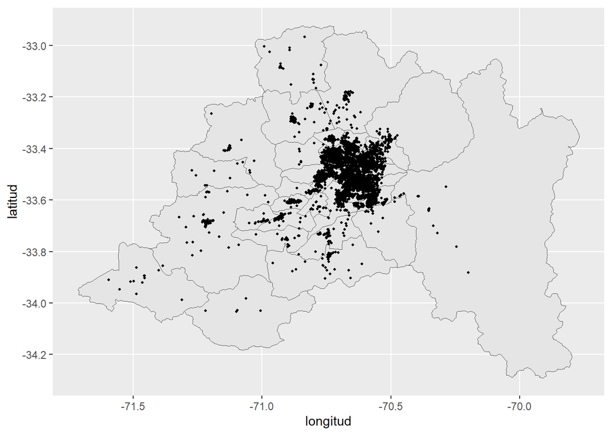

```r
# Ubicación de los colegios en la región metropolitana
ggplot(mapa_rm) +
  geom_sf(aes(geometry = geometry)) +
  geom_point(data = colegios_rm, aes(x = longitud, y = latitud), size = 0.8)
```

**Tarea 6.4** Generar un mapa que muestre el porcentaje de colegios con pago mayor a 100.000 pesos en la RM

```r
# Pago mensual
colegios_comuna <- anio_2021 %>%
  filter(cod_reg_rbd == 13) %>%
  filter( pago_mensual != "SIN INFORMACION" ) %>%
  group_by(cod_com_rbd, nom_com_rbd) %>%
  summarise(n_colegios = n()) %>%
  ungroup()

pago_mensual <- anio_2021 %>%
  filter(cod_reg_rbd == 13) %>%
  filter( pago_mensual != "SIN INFORMACION" ) %>%
  group_by(cod_com_rbd, pago_mensual) %>%
  summarise(contar = n()) %>%
  ungroup() %>%
  left_join(colegios_comuna, by = "cod_com_rbd") %>%
  mutate(porcentaje = contar / n_colegios * 100)

# Crear una tabla que contiene todos los tipos de pago para todas las comunas
comunas <- pago_mensual %>%
  group_by(cod_com_rbd, nom_com_rbd) %>%
  slice(1) %>%
  ungroup() %>%
  mutate(cod_com_rbd = as.character(cod_com_rbd)) %>%
  select(cod_com_rbd, nom_com_rbd)

#  Armar mapa con porcentaje de colegios que valen más de 100.000
mapa_rm2 <- mapa_rm %>%
  left_join(pago_mensual %>%
              mutate(cod_com_rbd = as.character(cod_com_rbd)) %>%
              filter(pago_mensual == "MAS DE $100.000"),
            by = c("codigo_comuna" = "cod_com_rbd")) %>%
  left_join(comunas,
            by = c("codigo_comuna" = "cod_com_rbd")) %>% # recuperar nombre de comunas que no tienen más de 100.000
  mutate(porcentaje = if_else(is.na(porcentaje), 0, porcentaje), # pasar a 0 las comunas que no tienen más de 100.000
         pago_mensual = if_else(is.na(pago_mensual), "MAS DE $100.000", pago_mensual),
         comuna = nom_com_rbd.y
         )
```

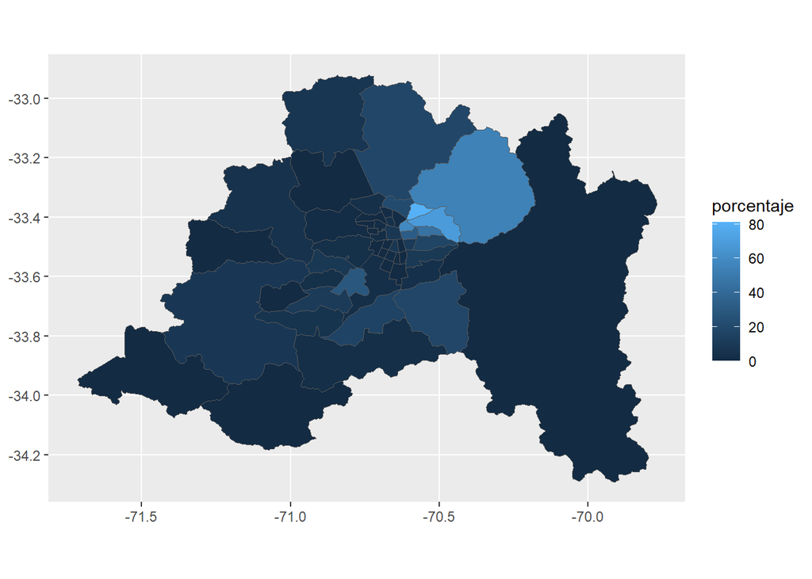

```r
ggplot(mapa_rm2) +
  geom_sf(aes(fill = porcentaje, geometry = geometry))
```